# Question

A spinner was constructed:

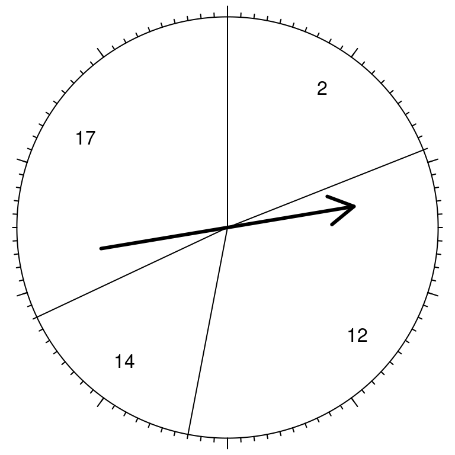

The spinner’s probability distribution is shown below.

| $x$ | $\mathbb{P}[x]$ |
| --- | --- |
| 2 | 0.19 |
| 12 | 0.34 |
| 14 | 0.15 |
| 17 | 0.32 |

It can also be downloaded as a csv.

## Answerlist

- What is the probability of spinning 12? In other words, what is $\mathbb{P}[X=12]$?
- What is the probability of spinning 2 or 17? In other words, what is $\mathbb{P}[X=2 ~\text{ or }~ X=17]$?
- If spinning twice, what is the probability of first spinning 2 and then spinning 17? In other words, what is $\mathbb{P}[X_1=2 ~\text{ and }~ X_2=17]$?
- What is the probability of spinning at least 14? In other words, what is $\mathbb{P}[X\ge 14]$?
- Determine the mean of the probability distribution by using $\mu = \sum x\cdot \mathbb{P}[x]$.
- Determine the standard deviation of the probability distribution by using $\sigma = \sqrt{\sum (x-\mu)^2 \cdot \mathbb{P}[x]}$.

# Solution

Make a table (for parts mean and standard deviation).

| $x$ | $\mathbb{P}[x]$ | $x\cdot\mathbb{P}[x]$ | $x-\mu$ | $(x-\mu)^2$ | $(x-\mu)^2 \cdot \mathbb{P}[x]$ |
| --- | --- | --- | --- | --- | --- |
| 2 | 0.19 | 0.38 | -10 | 100 | 19 |
| 12 | 0.34 | 4.08 | 0 | 0 | 0 |
| 14 | 0.15 | 2.1 | 2 | 4 | 0.6 |
| 17 | 0.32 | 5.44 | 5 | 25 | 8 |
| ========= | ========= | ========= | ========= | ========= | ========= |
|  |  | $\sum x \cdot \mathbb{P}[x)] = 12$ |  |  | $\sigma^2 = 27.6$ |
|  |  | $\mu = 12$ |  |  | $\sigma = 5.2535702$ |

## Answerlist

- 0.34
- $0.19 + 0.32$ = **0.51**
- $0.19 \times 0.32$ = **0.0608**
- 0.47
- $\mu = 12$
- $\sigma = 5.2535702$

# Meta-information

extype: cloze exsolution: 0.34|0.51|0.0608|0.47|12|5.2535702| exclozetype: num|num|num|num|num|num exname: probdist extol: 0.01 exextra[numwidth,logical]: TRUE